# Quantified Grad Student Analysis

```r
knitr::opts_chunk$set(tidy = FALSE, fig.height=4, cache=TRUE)
options(stringsAsFactors=FALSE)
## Loading Packages
require(dplyr)
require(lubridate)
require(ggplot2)
```

## Outline

I’ll be working with two datasets:

- `clock`: which is when I come into campus, and when I leave
- `gleeo`: which is the tracked time I spent on different tasks throughout each day

In this analysis I am going to:

1. load in the data
- add in a week count to gleeo and clock
- add the duration of campustime in clock
2. Answer the question: *How much time do I invest in Grad School?*, which can be broken down into
- how much time do I spend on campus, per day / week
- how much time am I working on grad school stuff, per day / week
- What percent of time that I am on campus am I actually getting work done?
- How efficient am I? (account for time worked not at campus)
- At the end I want to see “How many hours do I work a week”, so that has to be one output.

## import the data

```r
gleeo.df <- read.csv(file="2014-05-31_GleeoExport.csv", dec=".")
clock.df <- read.csv(file="2014-06-15_clocktime.csv")
# Renaming gleeo.df$Start.Date as date for ease of use
names(gleeo.df)[4] <- "date"
```

## Modify the data

### adding week count to `gleeo.df` and `clock.df`

I want to add in a week count, weeks start on Sunday. The reason for this is that I tend to think in week long work blocks.

```r
# saturday
format(as.Date("2014-06-7"), "%U")
```

```
## [1] "22"
```

```r
week("2014-06-07")
```

```
## [1] 23
```

```r
# sunday
format(as.Date("2014-06-8"), "%U")
```

```
## [1] "23"
```

So, apparently I can set something as a date, and then use the format function to get the week number. It seems that the week starts by default on a Sunday, so that’s neat.

since my times don’t span over a day, I only need to worry about one of the dates in my `gleeo` data frame

```r
# non-lubridate method
# gleeo.df$week <- format(ymd(gleeo.df$date), "%U")
#clock.df$week <- format(ymd(clock.df$date), "%U")

gleeo.df$week <- week(gleeo.df$date)
clock.df$week <- week(clock.df$date)
```

> I had the date in clocktime set as 3/3/2014, which is not the same as 2014-03-03, and hence `as.Date()` had issues with it. So I changed it in my google docs. Also it’s nice to have clock and gleeo have the same date format.

### Calculating time stuff

Go Go Lubridate

### Adding the weekday to `gleeo.df` and `clock.df`

```r
gleeo.df$day <- wday(gleeo.df$date, label=TRUE)
clock.df$day <- wday(clock.df$date, label=TRUE)
```

### extra days from the `clock.df`

Turns out I had an extra week in the beginning, and then a couple days at the end. So there’s more days in clock.df than there is in gleeo.df

```r
# clock.df <- clock.df[ymd(clock.df$date) %in% ymd(gleeo.df$date), ]
```

### Getting Tracked time

Here I’m just going to generate a lot of values, and deal with organizing them at the end.

```r
# Calculating campustime
clock.df$campustime <- interval(
         ymd_hms(paste(clock.df$date, clock.df$in_time)),
         ymd_hms(paste(clock.df$date, clock.df$out_time))
         ) / ehours(1)
```

## How much time do I invest in Grad School?

### how much time do I spend on campus, per day / week

Overall, what is the amount of time I spend on campus per day, let’s look at this with a density plot:

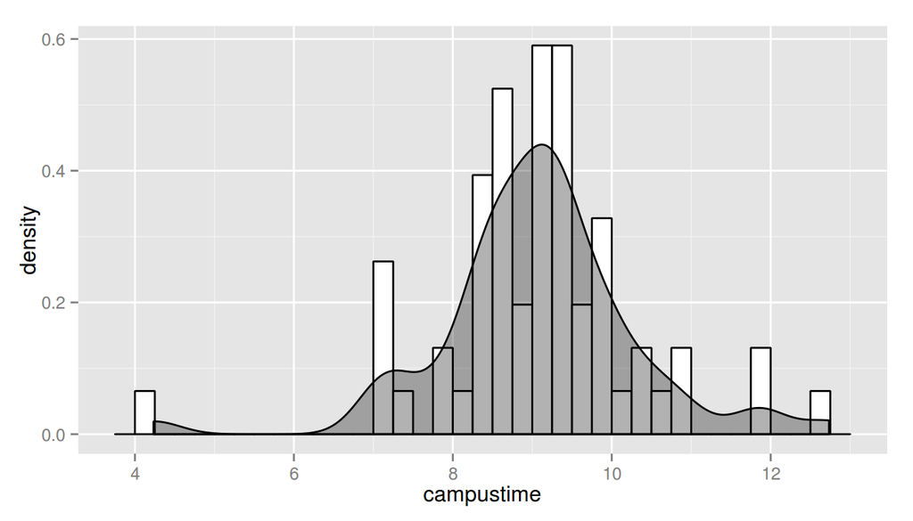

```r
ggplot(clock.df, aes(x=campustime)) +
    geom_histogram(aes(y=..density..),
                   binwidth=.25, color="black", fill="white") +
    geom_density(alpha=.3, fill="black")
```

Thinking about this, I expect there to be some structure to the times here, as I take a certain bus in, and then take a few possible busses back, so that would explain the lumps in the distribution.

```r
clock.df[which(clock.df$campustime <=5), ]
```

```
##          date in_time out_time week day campustime
## 52 2014-05-16 8:00:00 12:14:00   19 Fri      4.233
```

```r
# row 47, 2014-05-16
# clock.df<- filter(clock.df, date!= "2014-05-16" )
```

The outlier on Friday is one day when I left early, I was there only a half day (prelim season, just wanted to leave early).

```r
summary(clock.df$campustime)
```

```
##    Min. 1st Qu.  Median    Mean 3rd Qu.    Max.
##    4.23    8.50    9.12    9.08    9.63   12.70
```

So, my mean time spent on campus is 9.08 hrs per day.

For how much time I spend on campus per day, it might be interesting to look at the day (Monday - Sunday)

```r
clock.df %>% group_by(day) %>% summarize(daycampus = mean(campustime))
```

```
## Source: local data frame [5 x 2]
##
##     day daycampus
## 1   Mon     9.277
## 2  Tues     9.449
## 3   Wed     8.721
## 4 Thurs     9.645
## 5   Fri     8.315
```

```r
clock.df %>% group_by(day) %>% summarize(daycampus = sd(campustime))
```

```
## Source: local data frame [5 x 2]
##
##     day daycampus
## 1   Mon     0.742
## 2  Tues     1.212
## 3   Wed     1.251
## 4 Thurs     1.189
## 5   Fri     1.507
```

```r
anova(lm(campustime ~ day, data=clock.df))
```

```
## Analysis of Variance Table
##
## Response: campustime
##           Df Sum Sq Mean Sq F value Pr(>F)
## day        4   14.9    3.73    2.53   0.05 .
## Residuals 56   82.4    1.47
## ---
## Signif. codes:  0 '***' 0.001 '**' 0.01 '*' 0.05 '.' 0.1 ' ' 1
```

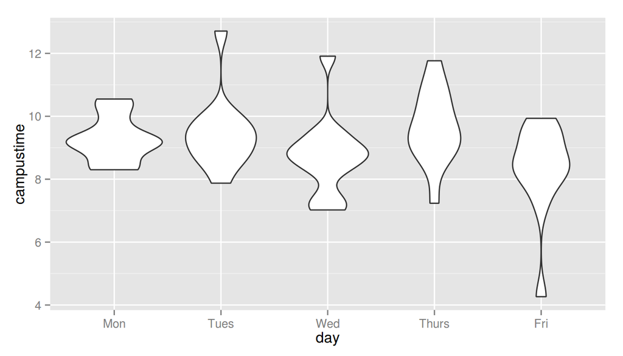

```r
# marginally signifacnt effect of day on the amount of time I spend on campus, surprising.

ggplot(clock.df, aes(x=day, y=campustime)) + geom_violin()
```

From the plots there’s definitely some outliers on Tues and Wed potentially, and there’s the half day on Friday coming in at around 4hrs.

#### and now, per week

Let’s look at the distribution of the data:

```r
weekclock <- clock.df %>% group_by(week) %>% summarize(weekcampus = sum(campustime))
# is there a week effect?
anova(lm(campustime ~ week, data=clock.df))
```

```
## Analysis of Variance Table
##
## Response: campustime
##           Df Sum Sq Mean Sq F value Pr(>F)
## week      12   27.7    2.31     1.6   0.12
## Residuals 48   69.6    1.45
```

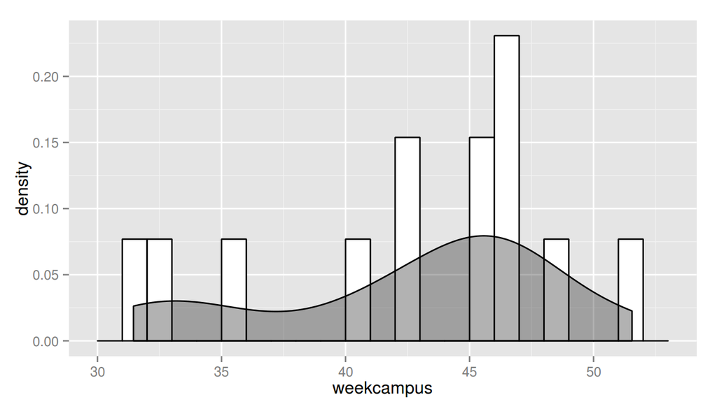

```r
# nope

ggplot(weekclock, aes(x=weekcampus)) +
    geom_histogram(aes(y=..density..),
                   binwidth=1, color="black", fill="white") +
    geom_density(alpha=.3, fill="black")
```

I guess I really don’t have enough points to see an interesting distribution. Maybe there’s a bimodal distribution. When I get more data I can see if that is actualy the case (maybe I have productive weeks, and unproductive weeks, and no inbetween)

Ok, what about a summary of the data

```r
summary(weekclock$weekcampus)
```

```
##    Min. 1st Qu.  Median    Mean 3rd Qu.    Max.
##    31.4    40.1    45.1    42.6    46.4    51.6
```

so, on average I spend 42.6 hours on campus a week.

#### In summary

I spend a mean of 9.08 hrs per day, and 42.6 hrs per week at campus

### how much time am I working on grad school stuff, per day / week

- this is the gleeo tracked time

```r
# Adding tracked time per day (trackedtime)
gleeotime <- gleeo.df %>% group_by(date) %>%
    summarize(tottrackedtime = sum(Decimal.Duration))

## adding time corrected for personal time
projtimes <- gleeo.df %>% group_by(Project, date) %>%
    summarize(totime = sum(Decimal.Duration))


perstime <- projtimes[which(projtimes$Project == "personal"), 2:3]
names(perstime)[2] <- "perstime"

# left join keeps all the rows of x, not y
trackedtime <- left_join(x=gleeotime, y=perstime, by="date")
# missing values of perstime are NAs, need to be zeros for further work.
trackedtime$perstime[is.na(trackedtime$perstime)] <- 0

# prodtime, tracked time doing productive things
trackedtime$prodtime <- trackedtime$tottrackedtime - trackedtime$perstime

trackedtime$day <- wday(ymd(trackedtime$date), label=TRUE)
trackedtime$week <- format(ymd(trackedtime$date), "%U")
```

Overall, how much productive time do I have per day?

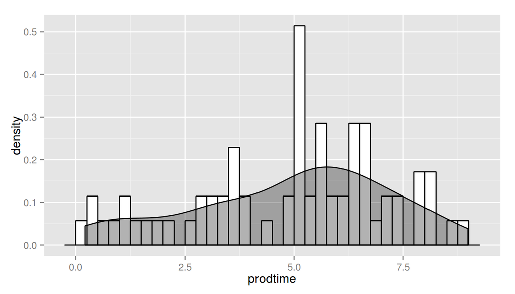

```r
ggplot(trackedtime, aes(x=prodtime)) +
    geom_histogram(aes(y=..density..),
                   binwidth=.25, color="black", fill="white") +
    geom_density(alpha=.3, fill="black")
```

Well, looks like my most common productive time is around 5 hours. The only thing is that this includes Saturday and Sunday. Let’s remove those and look at what I have

```r
trackedtime_MF <- trackedtime %>% filter(day != "Sat", day != "Sun")
summary(trackedtime_MF$prodtime)
```

```
##    Min. 1st Qu.  Median    Mean 3rd Qu.    Max.
##    2.70    5.02    5.72    5.73    6.70    8.98
```

```r
summary(trackedtime$prodtime)
```

```
##    Min. 1st Qu.  Median    Mean 3rd Qu.    Max.
##   0.217   3.490   5.210   4.930   6.550   8.980
```

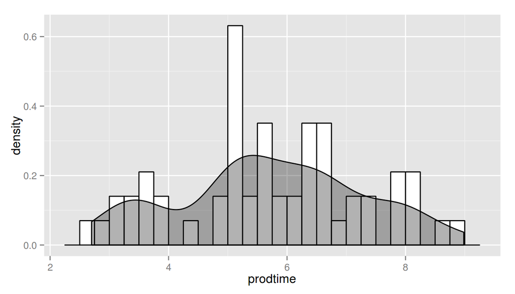

```r
# mean is definitely different
ggplot(trackedtime_MF, aes(x=prodtime)) +
    geom_histogram(aes(y=..density..),
                   binwidth=.25, color="black", fill="white") +
    geom_density(alpha=.3, fill="black")
```

So the mean productive time per work day is 5.73 hours.

For further work I am going to only be looking at weekday prodtime

How does my prodtime look as a function of each day?

```r
anova(lm(prodtime ~ day, trackedtime_MF))
```

```
## Analysis of Variance Table
##
## Response: prodtime
##           Df Sum Sq Mean Sq F value Pr(>F)
## day        4   20.2    5.05    2.26  0.075 .
## Residuals 52  115.9    2.23
## ---
## Signif. codes:  0 '***' 0.001 '**' 0.01 '*' 0.05 '.' 0.1 ' ' 1
```

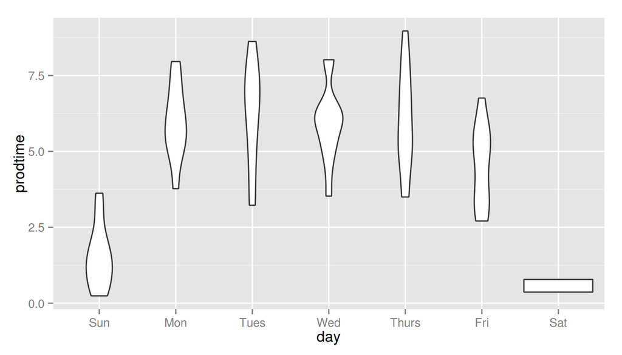

```r
ggplot(trackedtime, aes(x=day, y=prodtime)) +
    geom_violin()
```

Is my prodtime a function of week?

```r
anova(lm(prodtime ~ week, trackedtime_MF))
```

```
## Analysis of Variance Table
##
## Response: prodtime
##           Df Sum Sq Mean Sq F value Pr(>F)
## week      11   38.8    3.53    1.63   0.12
## Residuals 45   97.2    2.16
```

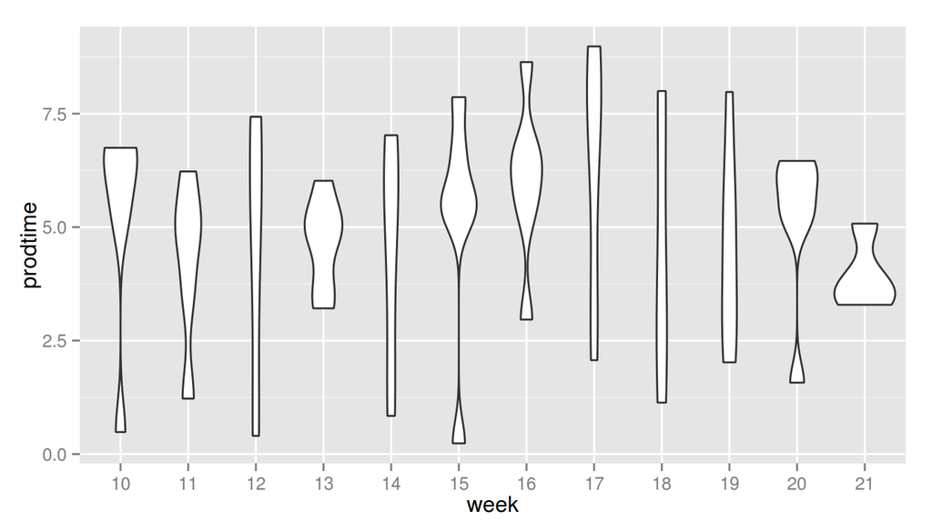

```r
ggplot(trackedtime, aes(x=week, y=prodtime)) +
    geom_violin()
```

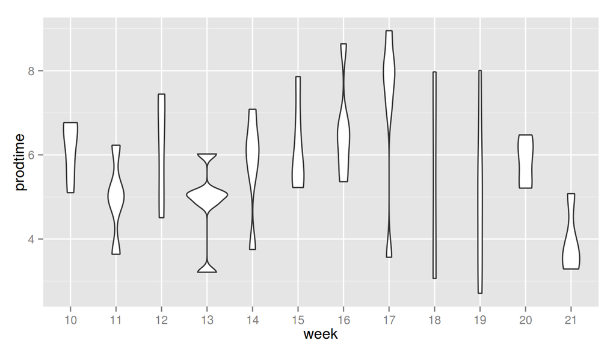

```r
ggplot(trackedtime_MF, aes(x=week, y=prodtime)) +
    geom_violin()
```

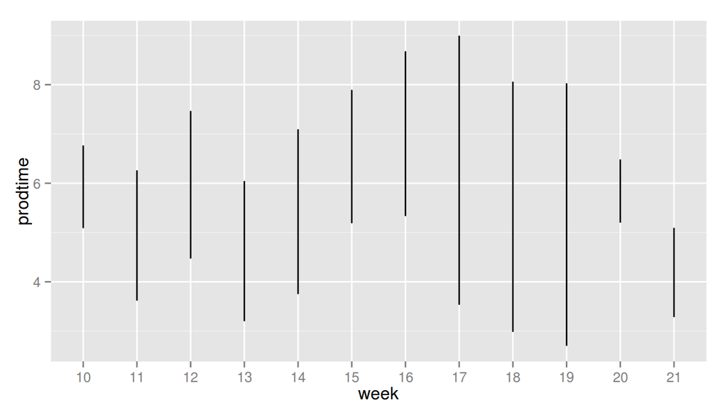

```r
ggplot(trackedtime_MF, aes(x=week, y=prodtime)) +
    geom_line()
```

How much prodtime do I have per week?

```r
trackedtime_MF_week <- trackedtime_MF %>% group_by(week) %>% summarize(weekprodtime = sum(prodtime))
summary(trackedtime_MF_week$weekprodtime)
```

```
##    Min. 1st Qu.  Median    Mean 3rd Qu.    Max.
##    15.8    23.7    29.0    27.2    30.9    35.7
```

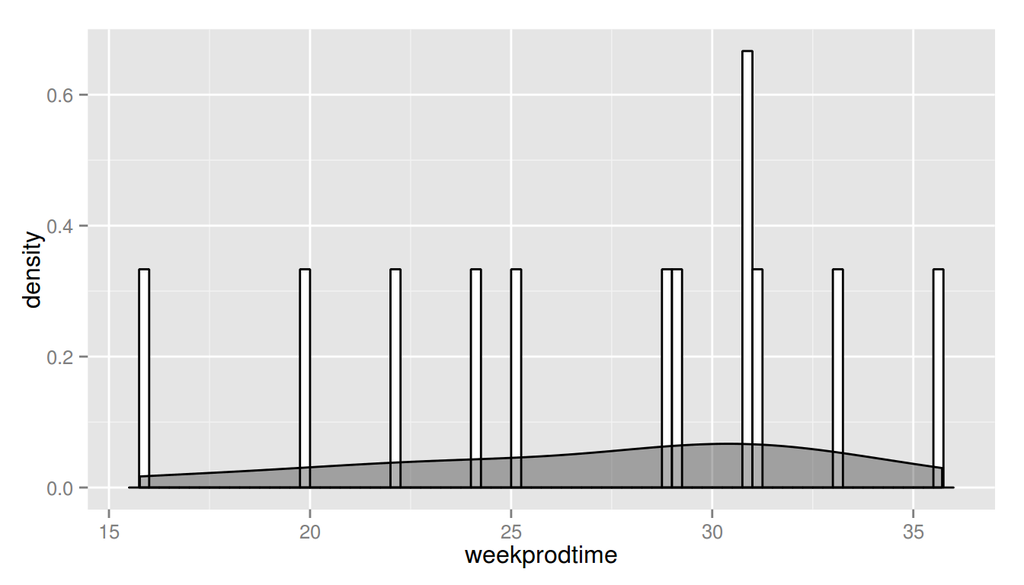

```r
ggplot(trackedtime_MF_week, aes(x=weekprodtime)) +
    geom_histogram(aes(y=..density..),
                   binwidth=.25, color="black", fill="white") +
    geom_density(alpha=.3, fill="black")
```

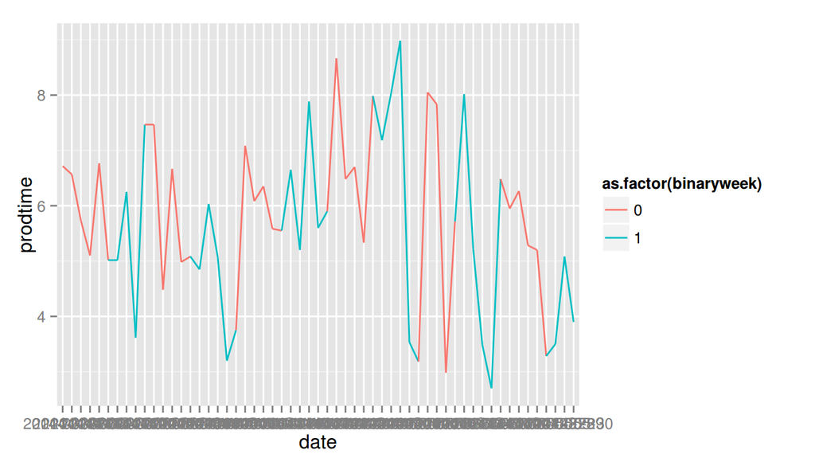

```r
binaryweek <- as.numeric(trackedtime_MF$week) %% 2

ggplot(trackedtime_MF, aes(x=date, y=prodtime, group=1, color=as.factor(binaryweek) )) + geom_line()
```

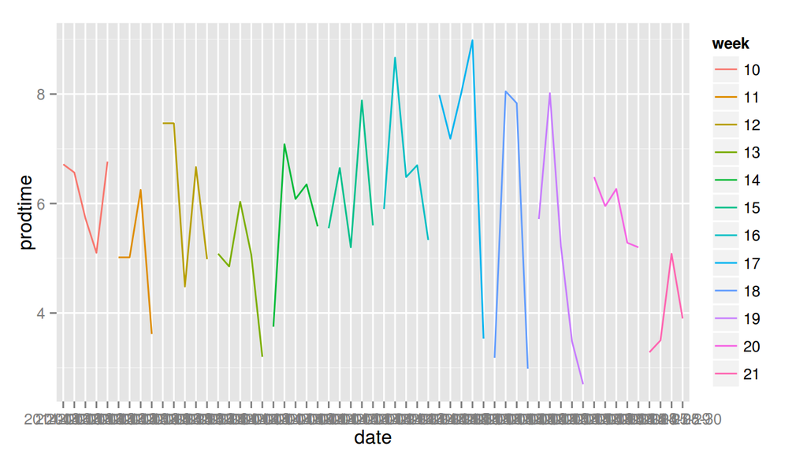

```r
ggplot(trackedtime_MF, aes(x=date, y=prodtime, group=week, color=week) ) + geom_line()
```

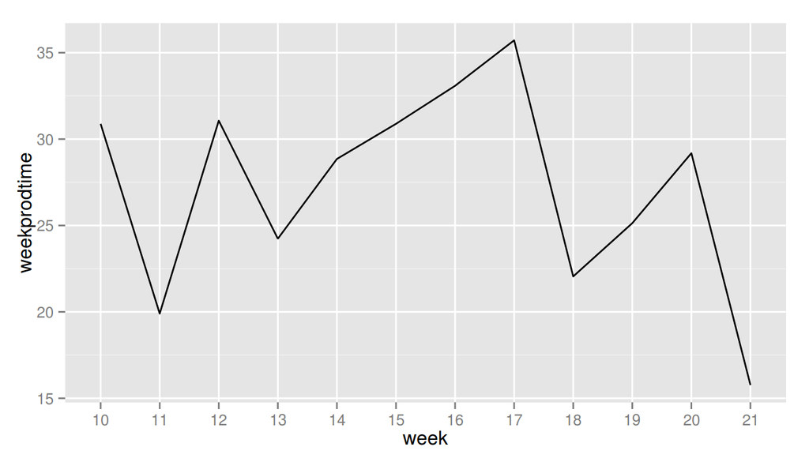

```r
ggplot(trackedtime_MF_week, aes(x=week, y=weekprodtime, group=1)) + geom_line()
```

Well, that distribution looks pretty crappy. More data will probably fill it in.

#### Summary

My mean productive time per work day is 5.73 hours per day, and 27.2 hours per week.

### What percent of time that I am on campus am I actually getting work done?

For this section I am going to calculate the amount of time that I am actually working while I am at campus. This is the amount of tracked time that falls within the interval when I am on campus. Then I am subtracting the amount of personal time per day.

```r
# pairing down clock.df into only those dates with tracked times
timeday.df <- clock.df[ ymd(clock.df$date) %in% ymd(gleeo.df$date), ]

campusinterval <- data.frame(date = timeday.df$date,
                             inter = interval(
         ymd_hms(paste(timeday.df$date, timeday.df$in_time)),
         ymd_hms(paste(timeday.df$date, timeday.df$out_time))
         ))

# pair down the intervals so there is only those dates with tracked times
campusinterval <- campusinterval[ymd(campusinterval$date) %in% ymd(gleeo.df$date), ]

gleeo.inst <- data.frame(date= gleeo.df$date,
                         inst= ymd_hm(paste(
                             gleeo.df$date, gleeo.df$Start.Time)))

# making a df that holds if the rows are in a campus interval
rowBoolean.df <- data.frame(date= gleeo.inst$date)
for(i in 1:length(campusinterval$inter)){
    rowBoolean.df<- cbind(rowBoolean.df, gleeo.inst$inst %within% campusinterval$inter[i])
}

# populate a new df with only the rows that are in the campus interval
    # grabbing the first iteration to make a df to catch the output
cinterGleeo.df <- gleeo.df[rowBoolean.df[, 2], ]
for(i in 3:length(names(rowBoolean.df))){
   cinterGleeo.df <- rbind(cinterGleeo.df,
                           gleeo.df[rowBoolean.df[, i], ])
}

# calc tracked time using the new df
catch <- cinterGleeo.df %>% group_by(date) %>% summarize(trackedCampusInterval= sum(Decimal.Duration))

timeday.df$trackedCampusInterval <- catch$trackedCampusInterval

# let's add columns for the total tracked time, perstime, and prodtime from the
# trackedtime data.frame
timeday.df <- left_join(timeday.df, trackedtime[1:4] )
#  calculate efficiency, prodtime
timeday.df$campusprodtime <- timeday.df$trackedCampusInterval-timeday.df$perstime
timeday.df$efficiency <- (timeday.df$campusprodtime) / timeday.df$campustime
```

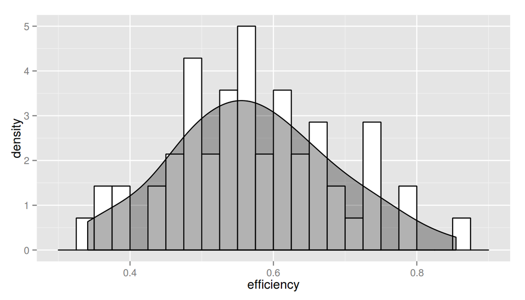

```r
ggplot(timeday.df, aes(x=efficiency)) +
    geom_histogram(aes(y=..density..),
                   binwidth=.025, color="black", fill="white") +
    geom_density(alpha=.3, fill="black")
```

```r
summary(timeday.df$efficiency)[c(1,4,6)]
```

```
##  Min.  Mean  Max.
## 0.341 0.572 0.855
```

### Efficiency per day, M-F

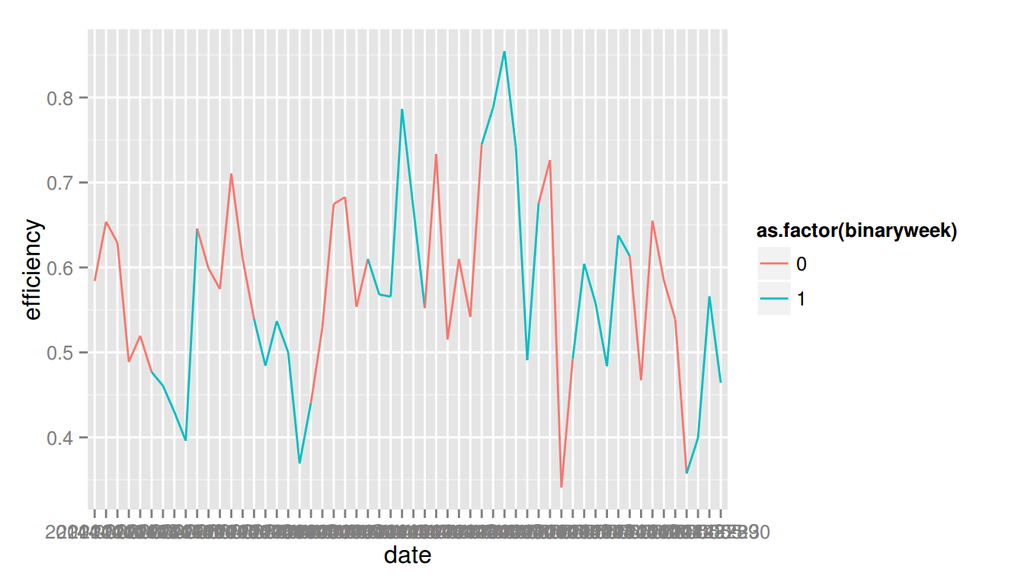

```r
binaryweek <- as.numeric(timeday.df$week) %% 2

ggplot(timeday.df, aes(x=date, y=efficiency, group=1, color=as.factor(binaryweek) )) + geom_line()
```

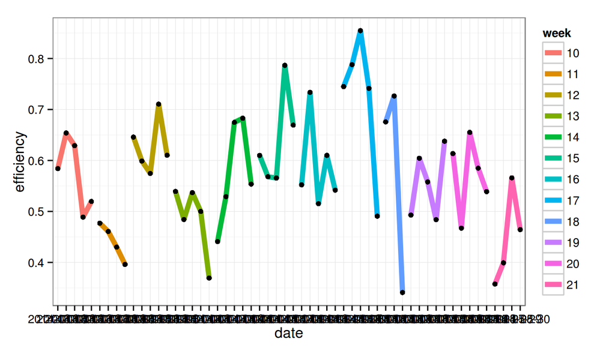

```r
ggplot(timeday.df, aes(x=date, y=efficiency, group=week, color=week )) +
    geom_line(size=2) + geom_point(color="black") + theme_bw()
```

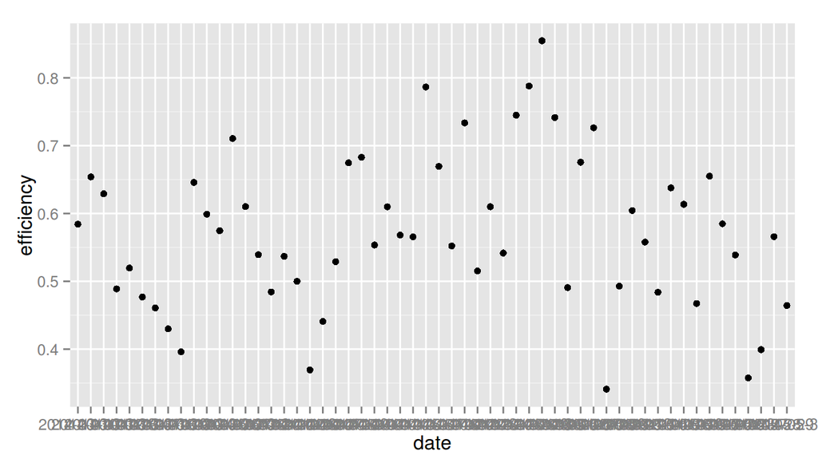

```r
ggplot(timeday.df, aes(x=date, y=efficiency)) + geom_point()
```

```r
anova(lm(efficiency ~ day, timeday.df))
```

```
## Analysis of Variance Table
##
## Response: efficiency
##           Df Sum Sq Mean Sq F value Pr(>F)
## day        4  0.046  0.0115    0.88   0.48
## Residuals 51  0.668  0.0131
```

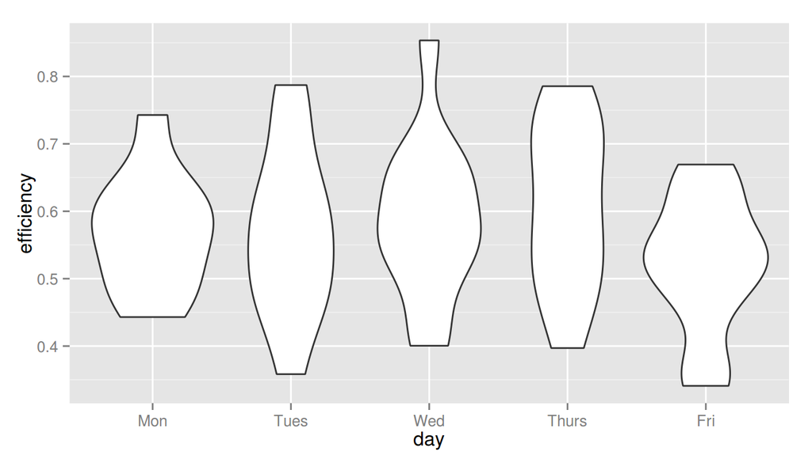

```r
ggplot(timeday.df, aes(x=day, y=efficiency)) +
    geom_violin()
```

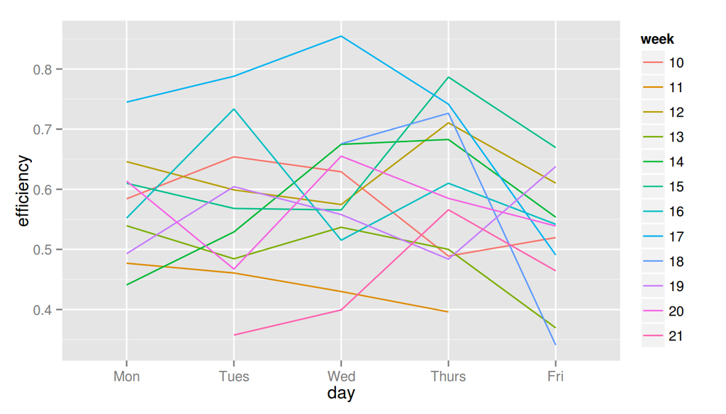

```r
ggplot(timeday.df, aes(x=day, y=efficiency, group= week, color= week)) + geom_line()
```

With that last graph I was trying to figure out a visualization for looking at if there is a trend as the week goes on

### Efficiency per day, by week

```r
anova(lm(efficiency ~ week, timeday.df))
```

```
## Analysis of Variance Table
##
## Response: efficiency
##           Df Sum Sq Mean Sq F value Pr(>F)
## week      11  0.326 0.02966    3.36  0.002 **
## Residuals 44  0.388 0.00882
## ---
## Signif. codes:  0 '***' 0.001 '**' 0.01 '*' 0.05 '.' 0.1 ' ' 1
```

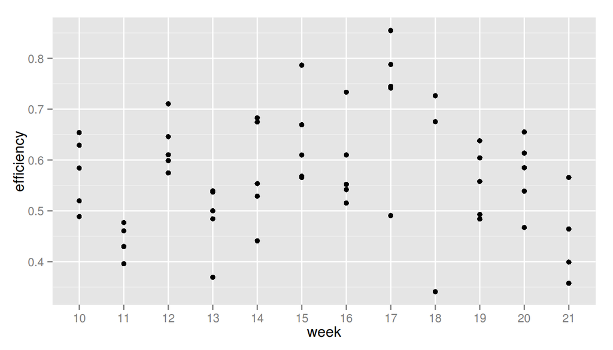

```r
ggplot(timeday.df, aes(x=week, y=efficiency, group=1)) + geom_point()
```

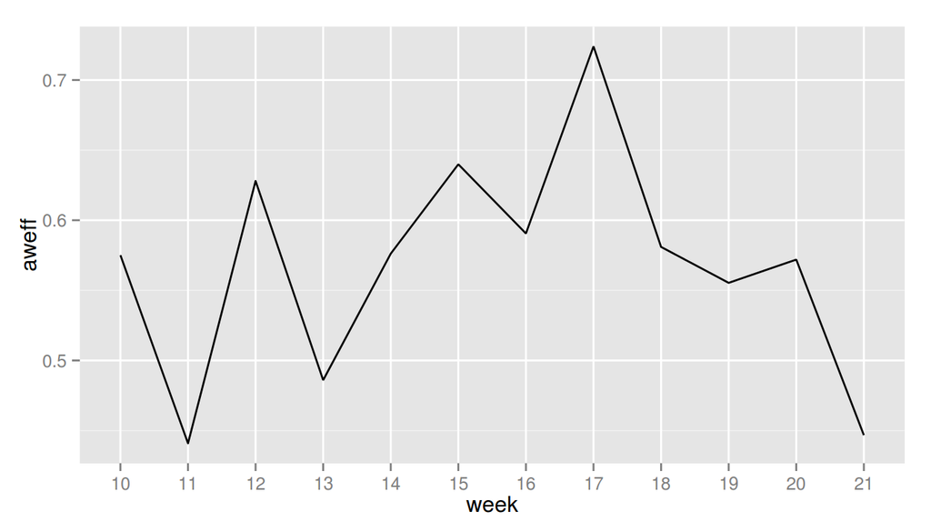

```r
timeweek.df <- timeday.df %>% group_by(week) %>% summarize(aweff= mean(efficiency), totwtrackedCampusInterval = sum(timeday.df$campusprodtime))
ggplot(timeweek.df, aes(x=week, y=aweff, group=1)) + geom_line()
```

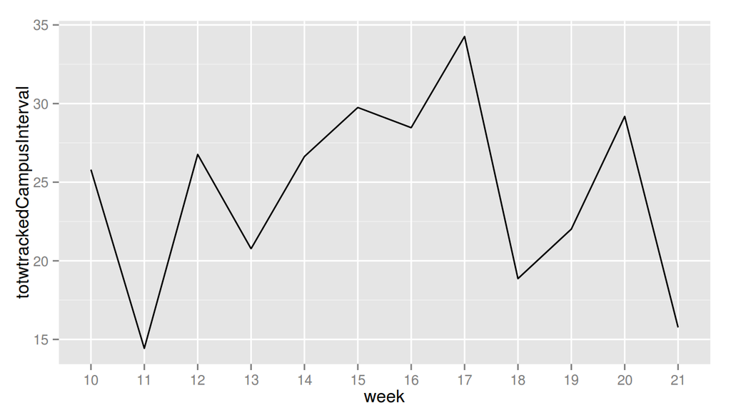

```r
ggplot(timeweek.df, aes(x=week, y=totwtrackedCampusInterval, group=1)) + geom_line()
```

With that last graph I was trying to figure out a visualization for looking at how the trend changes per week

#### In Summary

The average amount of time that I work during the time I am at campus is 5.23 hours per day, and 24.4 hours per week

## Relationships

### Productive time in the day for how much time I am at campus

This is looking at if the amount of stuff I get done during the day is affected by the amount of time I am on campus. Pretty much this is going to be looking at if I am at campus for a really long time, does the amount of work that I actually get done taper off.

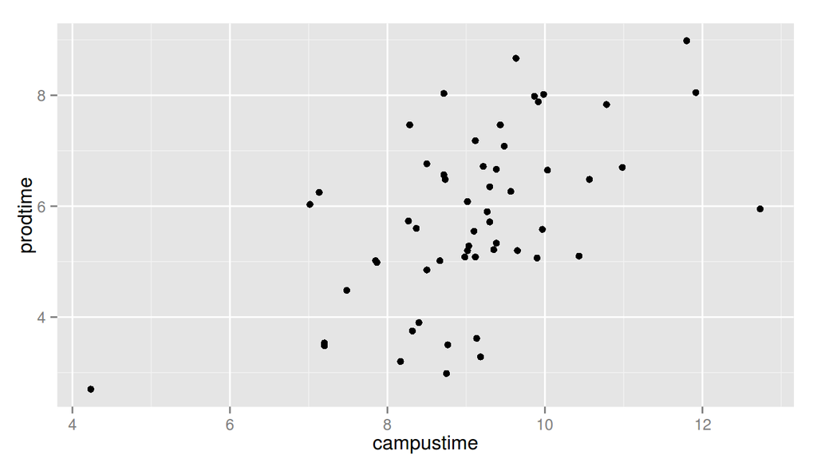

```r
ggplot(timeday.df, aes(x=campustime, y=prodtime)) + geom_point()
```

```r
anova(lm(prodtime ~ campustime, data=timeday.df))
```

```
## Analysis of Variance Table
##
## Response: prodtime
##            Df Sum Sq Mean Sq F value  Pr(>F)
## campustime  1   37.9    37.9    22.4 1.6e-05 ***
## Residuals  54   91.5     1.7
## ---
## Signif. codes:  0 '***' 0.001 '**' 0.01 '*' 0.05 '.' 0.1 ' ' 1
```

### Productive time at campus for how much time I am at campus

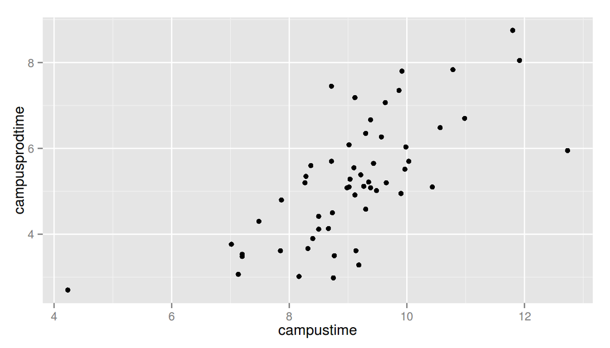

```r
ggplot(timeday.df, aes(x=campustime, y=campusprodtime)) + geom_point()
```

```r
anova(lm(campusprodtime ~ campustime, data=timeday.df))
```

```
## Analysis of Variance Table
##
## Response: campusprodtime
##            Df Sum Sq Mean Sq F value  Pr(>F)
## campustime  1   54.5    54.5      51 2.4e-09 ***
## Residuals  54   57.6     1.1
## ---
## Signif. codes:  0 '***' 0.001 '**' 0.01 '*' 0.05 '.' 0.1 ' ' 1
```

### Efficiency for how much time I am at campus

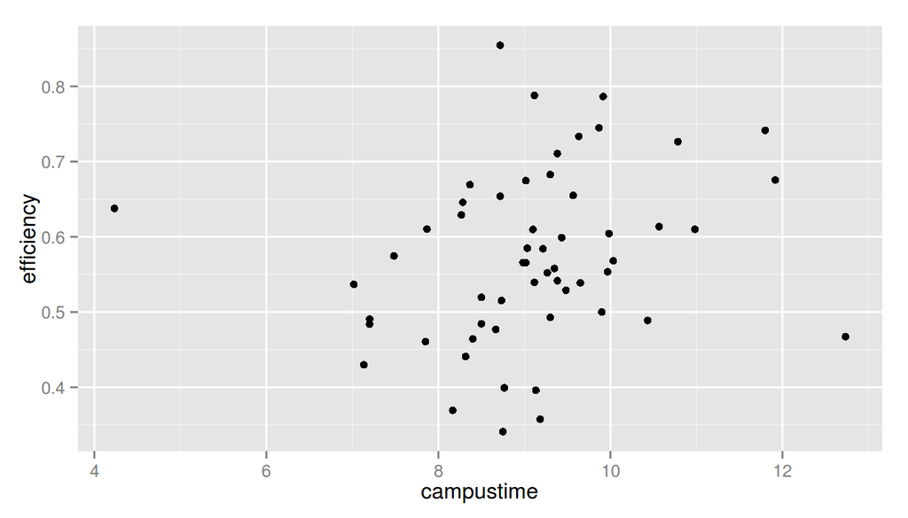

```r
ggplot(timeday.df, aes(x=campustime, y=efficiency)) + geom_point()
```

```r
anova(lm(efficiency ~ campustime, data=timeday.df))
```

```
## Analysis of Variance Table
##
## Response: efficiency
##            Df Sum Sq Mean Sq F value Pr(>F)
## campustime  1  0.034  0.0337    2.67   0.11
## Residuals  54  0.681  0.0126
```

### Amount of productive time given personal time?

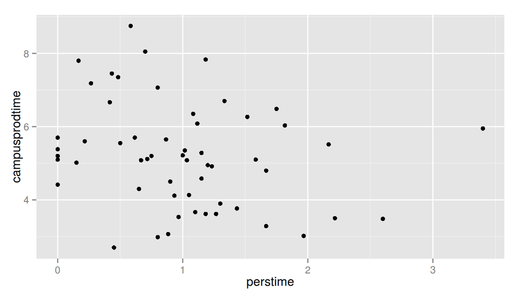

```r
ggplot(timeday.df, aes(x=perstime, y=campusprodtime)) + geom_point()
```

```r
anova(lm(campusprodtime ~ perstime, data=timeday.df))
```

```
## Analysis of Variance Table
##
## Response: campusprodtime
##           Df Sum Sq Mean Sq F value Pr(>F)
## perstime   1    6.1    6.06    3.09  0.085 .
## Residuals 54  106.0    1.96
## ---
## Signif. codes:  0 '***' 0.001 '**' 0.01 '*' 0.05 '.' 0.1 ' ' 1
```

## Saving useful Dataframes

This makes work in other report a little more concise

```r
save(clock.df, file="rep1_clock.df.Rdata")
save(gleeo.df, file="rep1_gleeo.df.Rdata")
save(timeday.df, file="rep1_timeday.df.Rdata")
save(cinterGleeo.df, file="rep1_cinterGleeo.df.Rdata")
save(trackedtime, file="rep1_trackedtime.df.Rdata")
```